# STA 506 - Midterm Examination

## **Question 3**: Sampling Distribution of Lognormal **Sample Mean** $\widehat{\mu_{LN}}$

We have derived two different estimators of lognormal population mean $\mu_{LN}$. This Question focuses on the sampling distribution of lognormal sample sample means based on MLE. The following are detailed instructions.

### (1). Write an R function to estimate the MLE of $\mu$ and $\sigma^2$, denoted by $\widehat{\mu}$ and $\widehat{\sigma^2}$ and return the MLE of $\mu_{LN}$, denoted by $\widehat{\mu_{LN}}$.

I will begin with writing an R function to estimate the $\mu$ and $\sigma^2$, which will be denoted as $\widehat{\mu}$ and $\widehat{\sigma^2}$. I will use this function to return the MLE of $\mu_{LN}$, denoted as $\widehat{\mu_{LN}}$.

```r
mle_lognormal <- function(x){
  y <- log(x)
  mu_hat <- mean(y)                   # MLE of mu
  sigma2_hat <- mean((y - mu_hat)^2)  # MLE of sigma^2
  muLN_hat <- exp(mu_hat + 0.5*sigma2_hat)  # MLE of the lognormal mean

  return(list(
    mu_hat = mu_hat,
    sigma2_hat = sigma2_hat,
    muLN_hat = muLN_hat     ))
}

mle_lognormal(eur)
```

```
$mu_hat
[1] 3.268536

$sigma2_hat
[1] 0.3271989

$muLN_hat
[1] 30.94264
```

So, $\widehat{\mu}$ = 3.268536, $\widehat{\sigma^2}$ = 0.3271989, and $\widehat{\mu_{LN}}$ = 30.94264.

### (2). Take 1000 Bootstrap samples from the raw oil data set. For each bootstrap sample, call the above R function to find the **bootstrap MLE** of $\mu_{LN}$, denoted by $\widehat{\mu_{LN}^*}^{(1)}, \widehat{\mu_{LN}^*}^{(2)}, \cdots, \widehat{\mu_{LN}^*}^{(1000)}$.

I will write some code to conduct the Bootstrap sampling process of the raw oil data set, the ‘eur’ data set. I will use this sampling process to find the bootstrap MLE of $\mu_{LN}$, denoted by $\widehat{\mu_{LN}^*}^{(1)}, \widehat{\mu_{LN}^*}^{(2)}, \cdots, \widehat{\mu_{LN}^*}^{(1000)}$.

```r
# Bootstrap sampling
set.seed(123)
B <- 1000    #1,000 bootstrap samples
boot_muLN <- numeric(B)
n <- length(eur)

for(i in 1:B){
boot_sample <- sample(eur, size = n, replace=TRUE)
boot_muLN[i] <- mle_lognormal(boot_sample)$muLN_hat
}
```

### (3). Using kernel density estimation approach to estimate the bootstrap density curves based on the bootstrap MLEs: $\widehat{\mu_{LN}^*}^{(1)}, \widehat{\mu_{LN}^*}^{(2)}, \cdots, \widehat{\mu_{LN}^*}^{(1000)}$.

I will use kernel density estimation to estimate the bootstrap density curve based on the bootstrap MLEs. I will plot this density curve.

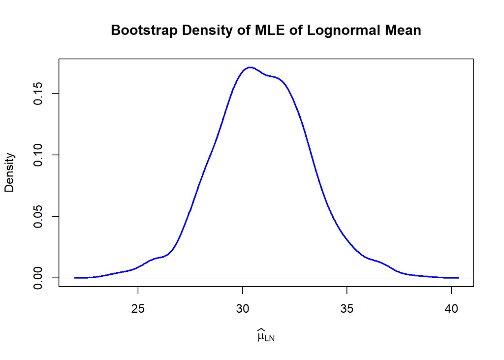

```r
# Kernel density estimate
boot_density <- density(boot_muLN)

plot(boot_density, main = "Bootstrap Density of MLE of Lognormal Mean",
     xlab = expression(widehat(mu)[LN]), lwd = 2, col = "blue")
```

The above plot shows the kernel density estimate for $\widehat\mu_{LN}$. It can be seen that this density curve follows what looks to be an approximately Normal distribution, seen by its unimodal and symmetric shape. The density curve shows no noticeable skew or outliers present.

### (4). In order to find the asymptotic sampling distribution using the **central limit theorem (CLT)**. That is, when sample size is large,

$$\bar{X} \to N \left(\mu_{LN}, \frac{\sigma_{LN}}{\sqrt{n}}\right)$$

where $\mu_{LN}$ and $\sigma_{LN}$ can be estimated by using the **plug-in principle of MLE**. Based on the asymptotic sampling distribution of **lognormal sample mean** $\bar{X}$, add the asymptotic density curve to the above Bootstrap kernel density curve.

I will add the asymptotic density curve to the Bootstrap kernel curve I created in the previous part. I will write R code to generate a CLT plug-in estimate, and then compare this density curve to the already existing Bootstrap kernel density curve.

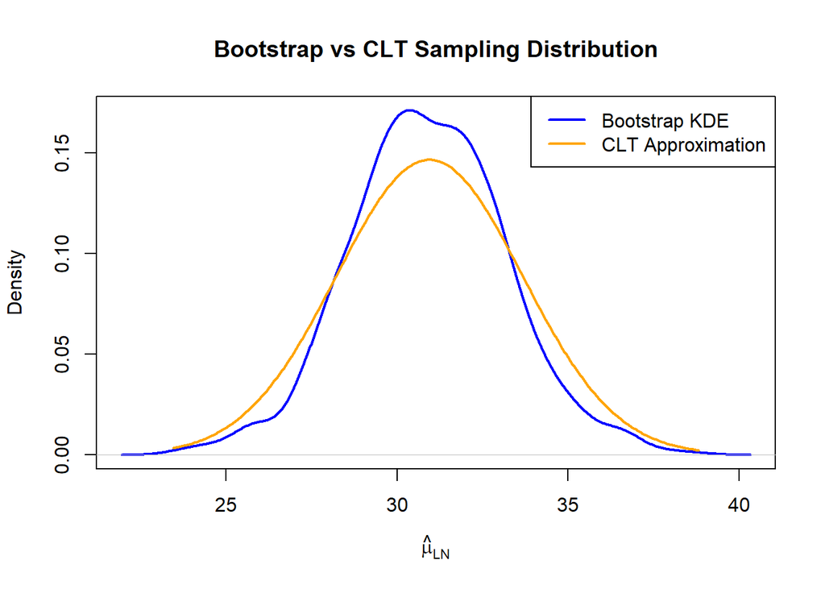

```r
# CLT plug-in estimates
fit <- mle_lognormal(eur)
mu_hat <- fit$mu_hat
sigma2_hat <- fit$sigma2_hat

muLN_hat <- exp(mu_hat + 0.5*sigma2_hat)
sigma2_LN_hat <- exp(2*mu_hat + sigma2_hat) * (exp(sigma2_hat) - 1)
sigma_LN_hat <- sqrt(sigma2_LN_hat)
n <- length(eur)

# Kernel density of Bootstrap MLEs
boot_density <- density(boot_muLN)

plot(boot_density,
     main="Bootstrap vs CLT Sampling Distribution",
     xlab=expression(hat(mu)[LN]),
     lwd=2, col="blue")

# Overlay CLT Normal curve
xvals <- seq(min(boot_muLN), max(boot_muLN), length=200)
clt_density <- dnorm(xvals,
                     mean=muLN_hat,
                     sd=sigma_LN_hat / sqrt(n))
lines(xvals, clt_density, col="orange", lwd=2)

legend("topright",
       legend=c("Bootstrap KDE","CLT Approximation"),
       col=c("blue","orange"),
       lwd=2)
```

The above plot shows the Bootstrap kernel density curve that I already found in the previous part, along with the asymptotic density curve from the CLT approximation.

### (5). Write a short summary to compare the two sampling distributions of the sample mean of the lognormal distribution.

As seen in the plot generated in the previous part, both the bootstrap kernel density estimate and the CLT approximation follow approximately Normal distributions, with a unimodal and symmetric shape and no noticeable skew or outliers.

The Bootstrap sampling distribution appears to have a sharper peak, with steeper tails in comparison to the CLT sampling distribution. Additionally, the Bootstrap sampling distribution does have a less “perfect” normal distribution shape in comparison. However, the overall shape of the Bootstrap sampling distribution can absolutely be considered as approximately normal, as its shape is very similar to that of a normal distribution and does not show any qualities which would make this a false classification.

On the other hand, the CLT approximation sampling distribution, based on the plug-in estimates, has wider tails and a less steep peak in comparison to the Bootstrap sampling distribution. The CLT approximation sampling distribution shows a near perfect normal distribution shape, meaning that without a doubt this CLT sampling distribution is normally distributed.

The Bootstrap method provides a sampling distribution that is very accurate to the data, and accounts for the potential variability in the sampling mean. The CLT approximation method provides use for theoretical calculations about overall trends regarding the sampling mean. The CLT method assumes normality due to the CLT itself stating that when a sample size is sufficiently large, the distribution of the sample mean will become approximately normal. Therefore, the CLT sampling distribution could potentially overlook skewness of the data if that is an issue. However, both of the sampling distributions appear to be similar enough that there does not seem to be any serious concerns.

Both density curves have a mean around the estimation that was found from the MLE in part 1, $\widehat{\mu_{LN}}$ = 30.94264. This indicates that both methods are useful in providing a meaningful estimate for the sample mean of the lognormal distribution.

## **Question 4**: Extra Bonus Credit

Derive the Hessian matrix by computing the second-order partial derivatives of the log-likelihood function (with respect to $\mu$ and $\sigma^2$). Then, translate the derived Hessian into an R function that takes the MLEs of the parameters and the data as inputs and returns the Hessian matrix. Finally, compare your analytically derived Hessian with the numerical Hessian returned by `optim()`.

To begin, the log-likelihood function was previously given, $\ell(\mu, \sigma^2) = -\frac{n}{2} \ln(2\pi) - n \ln \sigma - \sum_{i=1}^n \ln x_i - \frac{1}{2\sigma^2} \sum_{i=1}^n (\ln x_i - \mu)^2$

The first order partial derivative with respect to $\mu$ was found to be, $\frac{\partial \ell}{\partial \mu} = \frac{1}{\sigma^2} \sum_{i=1}^n (\ln x_i - \mu)$.

So, the second order partial derivative with respect to $\mu$ gives the following, $\frac{\partial^2 \ell}{\partial \mu^2} = -\frac{n}{\sigma^2}$.

Next, the first order partial derivative with respect to $\sigma^2$ was found to be, $\frac{\partial \ell}{\partial \sigma^2} = -\frac{n}{2\sigma^2} + \frac{1}{2\sigma^4} \sum_{i=1}^n (\ln x_i - \mu)^2$.

Previously, I used a substitution of $\beta = \sigma^2$ to make my differentiation simpler, so I will use this again. The first order partial derivative with respect to $\beta$ was: $\frac{\partial \ell}{\partial \beta} = -\frac{n}{2\beta} + \frac{1}{2\beta^2} \sum_{i=1}^n (\ln x_i - \mu)^2$.

I will take the derivative of this function with respect to $\beta$ to get the second order partial derivative. This results in the following: $\frac{\partial^2 \ell}{\partial (\beta)^2} = \frac{n}{2\beta^2} - \frac{1}{\beta^3} \sum_{i=1}^{n} (\ln x_i - \mu)^2$

Resubstituting $\sigma^2$ back in yields: $\frac{\partial^2 \ell}{\partial (\sigma^2)^2} = \frac{n}{2\sigma^4} - \frac{1}{\sigma^6} \sum_{i=1}^{n} (\ln x_i - \mu)^2$. Therefore, this is the second order partial derivative with respect to $\sigma^2$.

Finally, I will find the mixed partial derivative. I will start with the first order partial derivative that was found with respect to $\mu$, and then take the second order derivative of this with respect the $\sigma^2$. The first order partial derivative with respect to $\mu$ was $\frac{\partial \ell}{\partial \mu} = \frac{1}{\sigma^2} \sum_{i=1}^n (\ln x_i - \mu)$.

Taking the derivative of this existing derivative, but this time with respect to $\sigma^2$ results in the following: $\frac{\partial^2 \ell}{\partial \mu \partial \sigma^2} = - \frac{1}{(\sigma^2)^2} \sum_{i=1}^n (\ln x_i - \mu)$.

This can be simplified to $\frac{\partial^2 \ell}{\partial \mu \partial \sigma^2} = - \frac{1}{\sigma^4} \sum_{i=1}^n (\ln x_i - \mu)$.

Therefore, the mixed derivative of $\mu$ then $\sigma^2$ is $\frac{\partial^2 \ell}{\partial \mu \partial \sigma^2} = - \frac{1}{\sigma^4} \sum_{i=1}^n (\ln x_i - \mu)$.

Next, I will find the other mixed derivative. This time I will begin with the first order partial derivative with respect to $\sigma^2$ and then take the derivative of that with respect to $mu$. The first order derivative with respect to $\sigma^2$ was $\frac{\partial \ell}{\partial \sigma^2} = -\frac{n}{2\sigma^2} + \frac{1}{2\sigma^4} \sum_{i=1}^n (\ln x_i - \mu)^2$.

I will take the derivative of this with respect to $\mu$. This gives the following: $\frac{\partial^2 \ell}{\partial \sigma^2 \partial \mu} = 0 - \frac{1}{\sigma^4} \sum_{i=1}^n (\ln x_i - \mu)$.

Of course, we do not need this zero and it turns out that $\frac{\partial^2 \ell}{\partial \sigma^2 \partial \mu} = -\frac{1}{\sigma^4} \sum_{i=1}^n (\ln x_i - \mu)$.

Interestingly enough, it turns out that both of the mixed derivatives are the same.

The observed Hessian matrix at the MLE is formatted as follows.

$$\quad
\mathcal{H}(\hat{\mu}, \hat{\sigma}^2) =
\begin{bmatrix}
\frac{\partial^2 \ell}{\partial \mu^2} & \frac{\partial^2
\ell}{\partial \mu \partial \sigma^2} \\
\frac{\partial^2 \ell}{\partial \sigma^2 \partial \mu} &
\frac{\partial^2 \ell}{\partial (\sigma^2)^2}
\end{bmatrix}_{\mu = \hat{\mu}, \sigma^2 = \hat{\sigma}^2}$$
The final Hessian matrix for this problem is as follows.

$$\quad
\mathcal{H}(\hat{\mu}, \hat{\sigma}^2) =
\begin{bmatrix}
-\frac{n}{\sigma^2} & - \frac{1}{\sigma^4} \sum_{i=1}^n (\ln x_i -
\mu) \\
- \frac{1}{\sigma^4} \sum_{i=1}^n (\ln x_i - \mu) &
\frac{n}{2\sigma^4} - \frac{1}{\sigma^6} \sum_{i=1}^{n} (\ln x_i -
\mu)^2
\end{bmatrix}$$

Next, I will translate the derived Hessian into an R function. This R function will take the MLEs of the parameters and the data set as inputs and returns the Hessian matrix as output.

```r
# Hessian R function
hessian <- function(mu, sigma2, x){
n <- length(x)
y <- log(x)

# The terms within my matrix (note that the upper right and lower left were found to be equivalent, so I use the same term for both)
term1 <- -n/sigma2
term2 <- -(1/(sigma2^2))*sum(y-mu)
term3 <- (n/(2*sigma2^2)) - (1/(sigma2^3))*sum((y-mu)^2)

H <- matrix(c(term1, term2,
              term2, term3),
            nrow=2, byrow=TRUE)
return(H)
}
```

Now, I will calculate the numerical Hessian matrix that uses the MLEs of the parameters for the ‘eur’ data set and the above use of the optim() function.

```r
loglik <- function(par, x){
mu <- par[1]
sigma2 <- par[2]
y <- log(x)
n <- length(x)

# Log-likelihood function
ll <- -n/2*log(2*pi) - n/2*log(sigma2) - sum(log(x)) -
      (1/(2*sigma2))*sum((y-mu)^2)
return(-ll)}

fit <- optim(c(1,1), loglik, x=eur, hessian=TRUE)
fit$hessian
```

```
             [,1]         [,2]
[1,] 152.84782270  -0.04140131
[2,]  -0.04140131 233.74644704
```

The above values give the numerical Hessian matrix for the ‘eur’ data based upon the MLEs and the partial derivatives that I found. This above is the numerical Hessian matrix found from using the optim() function.

I will also calculate the analytical Hessian matrix for this data for comparison.

```r
fit_par <- fit$par
hessian(fit_par[1], fit_par[2], eur)
```

```
              [,1]          [,2]
[1,] -152.84782271    0.04140092
[2,]    0.04140092 -233.73334312
```